# QMM7301 Module 6 Applied Activity

## Soap Experiment [ANOVA]

A student investigated just how effective washing with soap is in eliminating bacteria. To do this she tested four different methods—washing with water only, washing with regular soap, washing with antibacterial soap, and spraying hands with antibacterial spray (containing 65% ethanol as an active ingredient).

1. State the null & alternative hypothesis
   $$H_0: μ.water= μ.watersoap = μ.antibacteria = μ.antibacterialspray \\
   H_A: \text{At Least one μ is different}$$
2. Perform a one-way ANOVA in R and print out the completed summary table.

```r
soap.anova<-aov(Bacterial.Counts~Method, data=soap.data)
summary(soap.anova)
```

```
##             Df Sum Sq Mean Sq F value  Pr(>F)
## Method       3  29882    9961   7.064 0.00111 **
## Residuals   28  39484    1410
## ---
## Signif. codes:  0 '***' 0.001 '**' 0.01 '*' 0.05 '.' 0.1 ' ' 1
```

3. Determine the critical F Values

F Value = 2.9466853

4. At 𝛼 = 0.05 state your decision regarding the null hypothesis
   $$\text{We reject the null. P.Value is less than 𝛼 of 0.05 meaning there
   is evidence that means of each experimental handwash method differ
   significantly}$$
5. Check the independence, equal variance, and normal population assumptions.

–> **Independence assumption** is met, she randomized the order of the experiments so they do not influence each other

We’ll check for equal variance below

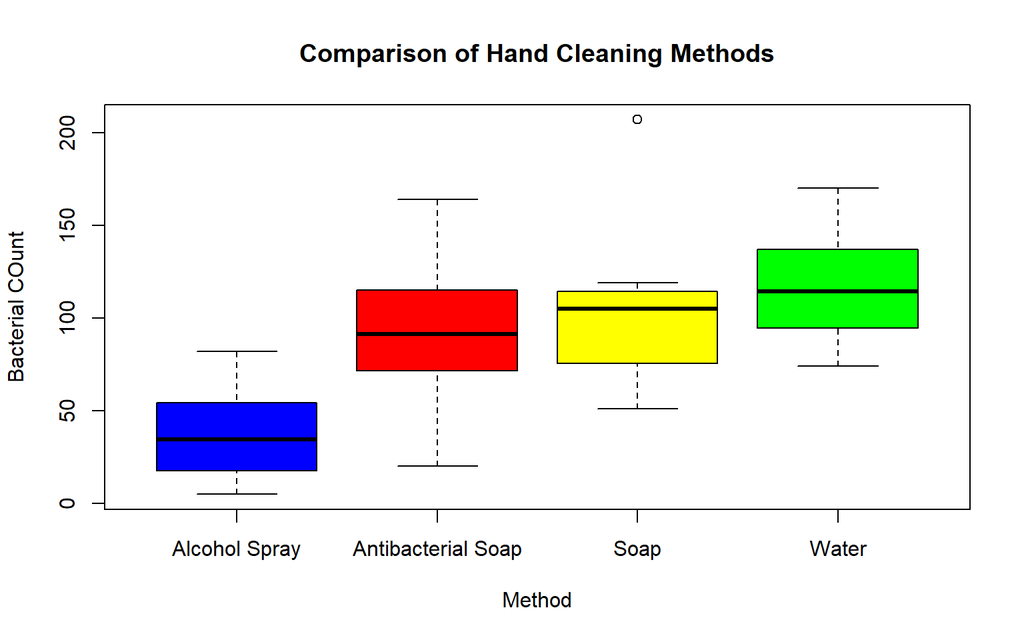

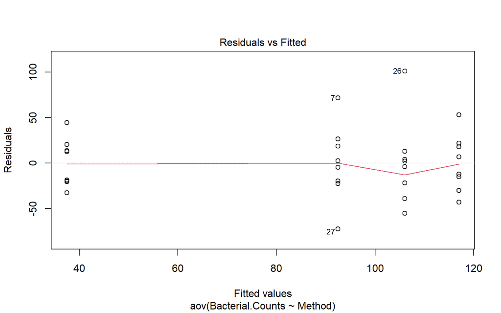

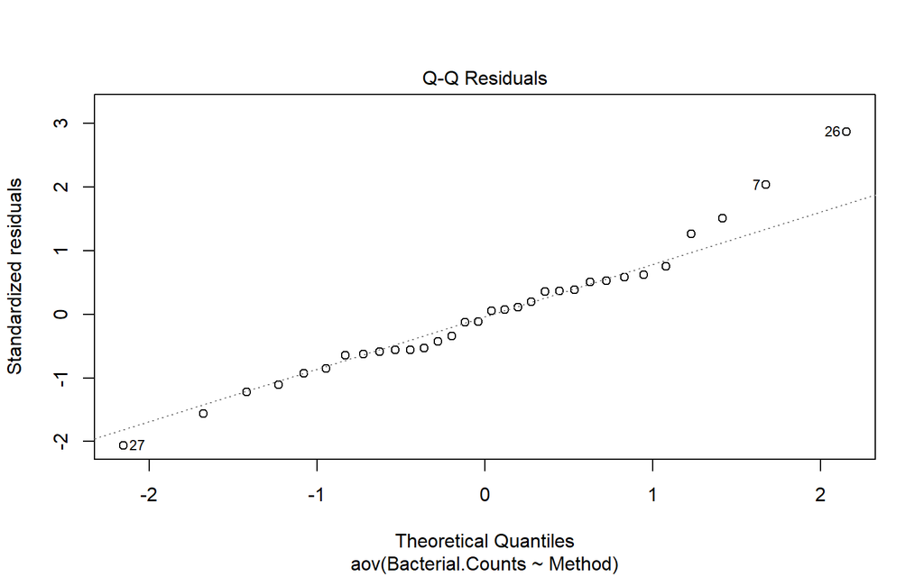

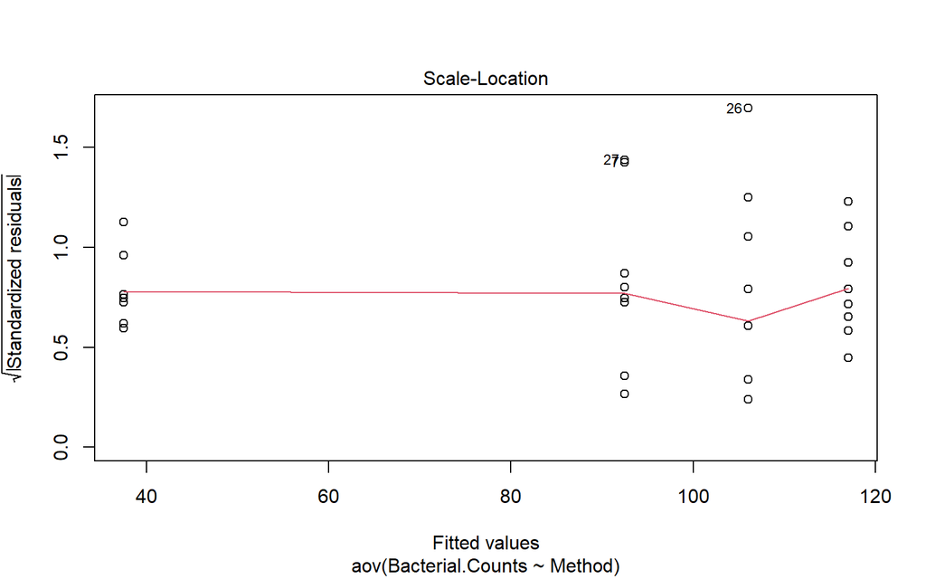

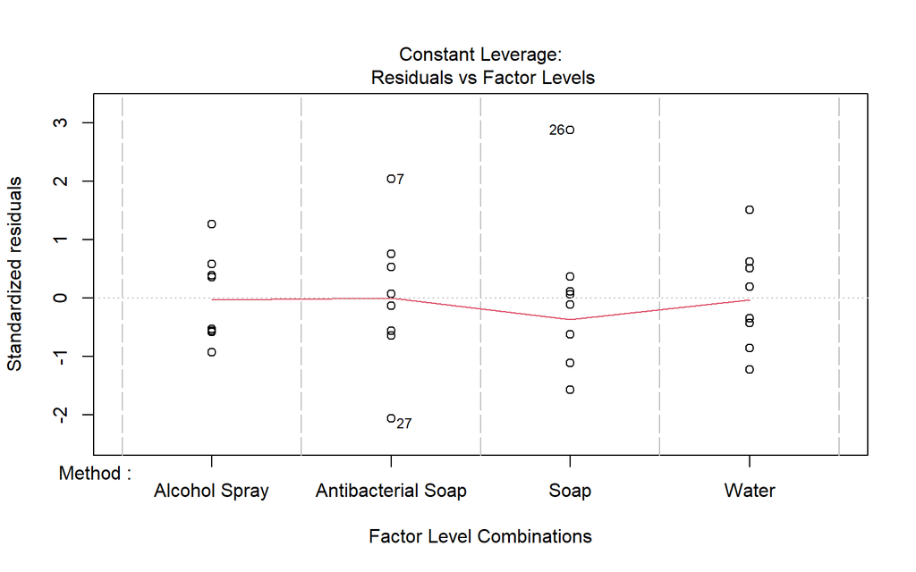

I built a boxplot to check for euqal variance visually.The soap method is a bit skewed with one very noticeable outlier. The residuals vs fitted is also almost horizontal so we can assume **equal variance** mostly holds

**Normal Population** assumption holds. On the Q-Q residual plot, the observations mostly close to the line

6. Create a bar plot with error bars for the average bacterial count for each hand washing method.

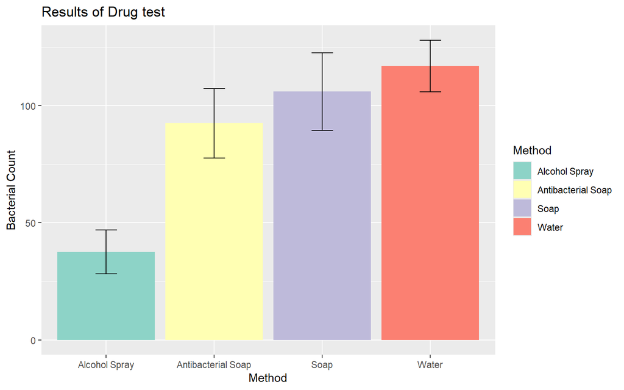

The alcohol spray looks to be the most effective having the least bacterial count by a very noticeable margin

7. Perform Tukey’s HSD test to confirm your results from the bar plot.

```r
TukeyHSD(soap.anova, conf.level=0.95)
```

```
##   Tukey multiple comparisons of means
##     95% family-wise confidence level
##
## Fit: aov(formula = Bacterial.Counts ~ Method, data = soap.data)
##
## $Method
##                                  diff        lwr       upr     p adj
## Antibacterial Soap-Alcohol Spray 55.0   3.735849 106.26415 0.0319648
## Soap-Alcohol Spray               68.5  17.235849 119.76415 0.0055672
## Water-Alcohol Spray              79.5  28.235849 130.76415 0.0012122
## Soap-Antibacterial Soap          13.5 -37.764151  64.76415 0.8886944
## Water-Antibacterial Soap         24.5 -26.764151  75.76415 0.5675942
## Water-Soap                       11.0 -40.264151  62.26415 0.9355196
```

| Method | Method |
| --- | --- |
| Soap | Antibacterial Soap |
| Water | Antibacterial Soap |
| Water | Soap |